# Risk Factor Analysis

## Outcome Variable

**Outcome Variable:** pers_wasted624

## Predictor Variables

**Intervention Variable:** ever_sstunted06

**Adjustment Set:**

- sex
- arm
- brthmon
- vagbrth
- single
- W_mage
- W_mhtcm
- W_mwtkg
- W_mbmi
- W_meducyrs
- W_feducyrs
- W_parity
- delta_brthmon
- delta_vagbrth
- delta_single
- delta_W_mage
- delta_W_mhtcm
- delta_W_mwtkg
- delta_W_mbmi
- delta_W_meducyrs
- delta_W_feducyrs
- delta_W_parity

## Stratifying Variables

The analysis was stratified on these variable(s):

- studyid
- country

## Data Summary

| studyid | country | ever_sstunted06 | pers_wasted624 | n_cell | n | outcome_variable |
| --- | --- | --- | --- | --- | --- | --- |
| CMC-V-BCS-2002 | INDIA | 0 | 0 | 260 | 370 | pers_wasted624 |
| CMC-V-BCS-2002 | INDIA | 0 | 1 | 16 | 370 | pers_wasted624 |
| CMC-V-BCS-2002 | INDIA | 1 | 0 | 82 | 370 | pers_wasted624 |
| CMC-V-BCS-2002 | INDIA | 1 | 1 | 12 | 370 | pers_wasted624 |
| CMIN | BANGLADESH | 0 | 0 | 181 | 252 | pers_wasted624 |
| CMIN | BANGLADESH | 0 | 1 | 12 | 252 | pers_wasted624 |
| CMIN | BANGLADESH | 1 | 0 | 46 | 252 | pers_wasted624 |
| CMIN | BANGLADESH | 1 | 1 | 13 | 252 | pers_wasted624 |
| COHORTS | GUATEMALA | 0 | 0 | 843 | 1023 | pers_wasted624 |
| COHORTS | GUATEMALA | 0 | 1 | 24 | 1023 | pers_wasted624 |
| COHORTS | GUATEMALA | 1 | 0 | 139 | 1023 | pers_wasted624 |
| COHORTS | GUATEMALA | 1 | 1 | 17 | 1023 | pers_wasted624 |
| COHORTS | INDIA | 0 | 0 | 5774 | 6893 | pers_wasted624 |
| COHORTS | INDIA | 0 | 1 | 648 | 6893 | pers_wasted624 |
| COHORTS | INDIA | 1 | 0 | 348 | 6893 | pers_wasted624 |
| COHORTS | INDIA | 1 | 1 | 123 | 6893 | pers_wasted624 |
| COHORTS | PHILIPPINES | 0 | 0 | 2411 | 2809 | pers_wasted624 |
| COHORTS | PHILIPPINES | 0 | 1 | 184 | 2809 | pers_wasted624 |
| COHORTS | PHILIPPINES | 1 | 0 | 172 | 2809 | pers_wasted624 |
| COHORTS | PHILIPPINES | 1 | 1 | 42 | 2809 | pers_wasted624 |
| CONTENT | PERU | 0 | 0 | 207 | 215 | pers_wasted624 |
| CONTENT | PERU | 0 | 1 | 0 | 215 | pers_wasted624 |
| CONTENT | PERU | 1 | 0 | 8 | 215 | pers_wasted624 |
| CONTENT | PERU | 1 | 1 | 0 | 215 | pers_wasted624 |
| EE | PAKISTAN | 0 | 0 | 188 | 373 | pers_wasted624 |
| EE | PAKISTAN | 0 | 1 | 24 | 373 | pers_wasted624 |
| EE | PAKISTAN | 1 | 0 | 136 | 373 | pers_wasted624 |
| EE | PAKISTAN | 1 | 1 | 25 | 373 | pers_wasted624 |
| GMS-Nepal | NEPAL | 0 | 0 | 454 | 590 | pers_wasted624 |
| GMS-Nepal | NEPAL | 0 | 1 | 88 | 590 | pers_wasted624 |

[output cut: 90 more lines]

The following strata were considered:

- studyid: CMC-V-BCS-2002, country: INDIA
- studyid: CMIN, country: BANGLADESH
- studyid: COHORTS, country: GUATEMALA
- studyid: COHORTS, country: INDIA
- studyid: COHORTS, country: PHILIPPINES
- studyid: CONTENT, country: PERU
- studyid: EE, country: PAKISTAN
- studyid: GMS-Nepal, country: NEPAL
- studyid: Guatemala BSC, country: GUATEMALA
- studyid: IRC, country: INDIA
- studyid: JiVitA-3, country: BANGLADESH
- studyid: JiVitA-4, country: BANGLADESH
- studyid: Keneba, country: GAMBIA
- studyid: LCNI-5, country: MALAWI
- studyid: MAL-ED, country: BANGLADESH
- studyid: MAL-ED, country: BRAZIL
- studyid: MAL-ED, country: INDIA
- studyid: MAL-ED, country: NEPAL
- studyid: MAL-ED, country: PERU
- studyid: MAL-ED, country: SOUTH AFRICA
- studyid: MAL-ED, country: TANZANIA, UNITED REPUBLIC OF
- studyid: NIH-Birth, country: BANGLADESH
- studyid: NIH-Crypto, country: BANGLADESH
- studyid: PROBIT, country: BELARUS
- studyid: PROVIDE, country: BANGLADESH
- studyid: ResPak, country: PAKISTAN
- studyid: SAS-CompFeed, country: INDIA
- studyid: SAS-FoodSuppl, country: INDIA
- studyid: TanzaniaChild2, country: TANZANIA, UNITED REPUBLIC OF
- studyid: ZVITAMBO, country: ZIMBABWE

### Dropped Strata

Some strata were dropped due to rare outcomes:

- studyid: CONTENT, country: PERU
- studyid: Guatemala BSC, country: GUATEMALA
- studyid: LCNI-5, country: MALAWI
- studyid: MAL-ED, country: BANGLADESH
- studyid: MAL-ED, country: BRAZIL
- studyid: MAL-ED, country: NEPAL
- studyid: MAL-ED, country: PERU
- studyid: MAL-ED, country: SOUTH AFRICA
- studyid: MAL-ED, country: TANZANIA, UNITED REPUBLIC OF
- studyid: PROBIT, country: BELARUS
- studyid: PROVIDE, country: BANGLADESH

## Methods Detail

We’re interested in the causal parameters $E[Y_a]$ for all values of $a \in \mathcal{A}$. These parameters represent the mean outcome if, possibly contrary to fact, we intervened to set all units to have $A=a$. Under the randomization and positivity assumptions, these are identified by the statistical parameters $\psi_a=E_W[E_{Y|A,W}(Y|A=a,W)]$. In addition, we’re interested in the mean of $Y$, $E[Y]$ under no intervention (the observed mean). We will estimate these parameters by using SuperLearner to fit the relevant likelihood factors – $E_{Y|A,W}(Y|A=a,W)$ and $p(A=a|W)$, and then updating our likelihood fit using a joint TMLE.

For unadjusted analyses ($W=\{\}$), initial likelihoods were estimated using Lrnr_glm to estimate the simple $E(Y|A)$ and Lrnr_mean to estimate $p(A)$. For adjusted analyses, a small library containing Lrnr_glmnet, Lrnr_xgboost, and Lrnr_mean was used.

Having estimated these parameters, we will then use the delta method to estimate relative risks and attributable risks relative to a prespecified baseline level of $A$.

[output not shown]

[output not shown]

[output not shown]

# Results Detail

## Results Plots

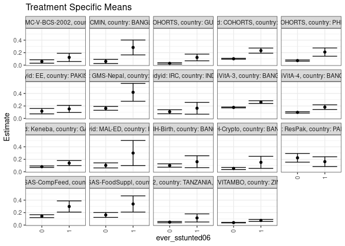

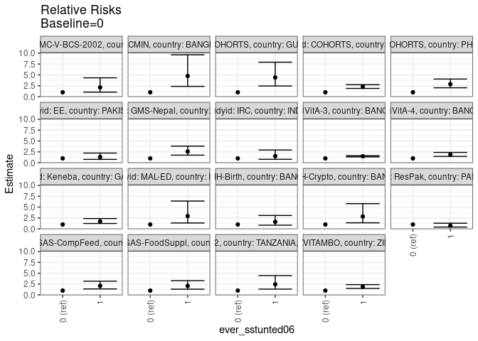

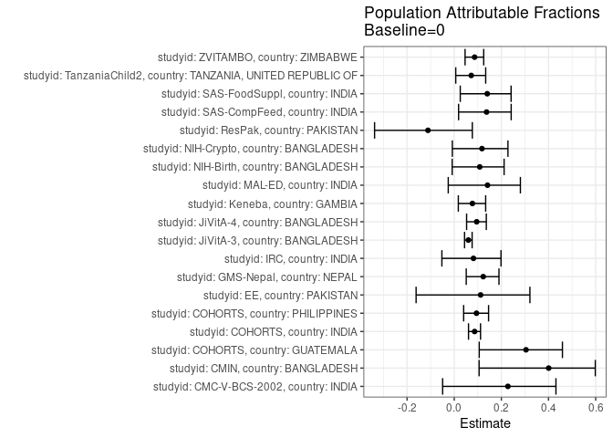

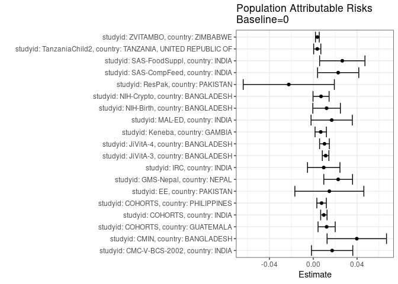

## Results Table

### Parameter: TSM

| studyid | country | intervention_level | baseline_level | estimate | ci_lower | ci_upper |
| --- | --- | --- | --- | --- | --- | --- |
| CMC-V-BCS-2002 | INDIA | 0 | NA | 0.0584459 | 0.0308255 | 0.0860663 |
| CMC-V-BCS-2002 | INDIA | 1 | NA | 0.1238636 | 0.0577832 | 0.1899439 |
| CMIN | BANGLADESH | 0 | NA | 0.0594613 | 0.0258138 | 0.0931087 |
| CMIN | BANGLADESH | 1 | NA | 0.2828869 | 0.1635341 | 0.4022396 |
| COHORTS | GUATEMALA | 0 | NA | 0.0278712 | 0.0168705 | 0.0388720 |
| COHORTS | GUATEMALA | 1 | NA | 0.1229530 | 0.0693573 | 0.1765487 |
| COHORTS | INDIA | 0 | NA | 0.1021815 | 0.0947334 | 0.1096295 |
| COHORTS | INDIA | 1 | NA | 0.2331089 | 0.1920377 | 0.2741801 |
| COHORTS | PHILIPPINES | 0 | NA | 0.0728612 | 0.0627478 | 0.0829746 |
| COHORTS | PHILIPPINES | 1 | NA | 0.2093635 | 0.1433986 | 0.2753284 |
| EE | PAKISTAN | 0 | NA | 0.1166664 | 0.0726063 | 0.1607265 |
| EE | PAKISTAN | 1 | NA | 0.1527668 | 0.0960632 | 0.2094704 |
| GMS-Nepal | NEPAL | 0 | NA | 0.1619968 | 0.1309044 | 0.1930893 |
| GMS-Nepal | NEPAL | 1 | NA | 0.4188970 | 0.2756425 | 0.5621514 |
| IRC | INDIA | 0 | NA | 0.1075188 | 0.0751071 | 0.1399305 |
| IRC | INDIA | 1 | NA | 0.1636893 | 0.0692758 | 0.2581027 |
| JiVitA-3 | BANGLADESH | 0 | NA | 0.1765111 | 0.1695383 | 0.1834839 |
| JiVitA-3 | BANGLADESH | 1 | NA | 0.2617560 | 0.2396818 | 0.2838302 |
| JiVitA-4 | BANGLADESH | 0 | NA | 0.0970613 | 0.0859809 | 0.1081416 |
| JiVitA-4 | BANGLADESH | 1 | NA | 0.1810527 | 0.1434300 | 0.2186753 |
| Keneba | GAMBIA | 0 | NA | 0.0814812 | 0.0695615 | 0.0934010 |
| Keneba | GAMBIA | 1 | NA | 0.1389878 | 0.0983239 | 0.1796517 |
| MAL-ED | INDIA | 0 | NA | 0.1023256 | 0.0617274 | 0.1429237 |
| MAL-ED | INDIA | 1 | NA | 0.3000000 | 0.0987348 | 0.5012652 |
| NIH-Birth | BANGLADESH | 0 | NA | 0.1003697 | 0.0732302 | 0.1275093 |
| NIH-Birth | BANGLADESH | 1 | NA | 0.1611108 | 0.0658054 | 0.2564162 |
| NIH-Crypto | BANGLADESH | 0 | NA | 0.0531758 | 0.0362619 | 0.0700896 |
| NIH-Crypto | BANGLADESH | 1 | NA | 0.1509434 | 0.0544976 | 0.2473892 |
| ResPak | PAKISTAN | 0 | NA | 0.2232267 | 0.1536308 | 0.2928226 |
| ResPak | PAKISTAN | 1 | NA | 0.1619192 | 0.0834362 | 0.2404021 |
| SAS-CompFeed | INDIA | 0 | NA | 0.1429622 | 0.1196036 | 0.1663207 |
| SAS-CompFeed | INDIA | 1 | NA | 0.2980820 | 0.2086379 | 0.3875261 |
| SAS-FoodSuppl | INDIA | 0 | NA | 0.1625583 | 0.1227726 | 0.2023441 |
| SAS-FoodSuppl | INDIA | 1 | NA | 0.3382156 | 0.2087719 | 0.4676593 |
| TanzaniaChild2 | TANZANIA, UNITED REPUBLIC OF | 0 | NA | 0.0468966 | 0.0374300 | 0.0563631 |
| TanzaniaChild2 | TANZANIA, UNITED REPUBLIC OF | 1 | NA | 0.1144318 | 0.0496672 | 0.1791965 |
| ZVITAMBO | ZIMBABWE | 0 | NA | 0.0394974 | 0.0355995 | 0.0433953 |
| ZVITAMBO | ZIMBABWE | 1 | NA | 0.0745387 | 0.0591515 | 0.0899259 |

### Parameter: E(Y)

| studyid | country | intervention_level | baseline_level | estimate | ci_lower | ci_upper |
| --- | --- | --- | --- | --- | --- | --- |
| CMC-V-BCS-2002 | INDIA | NA | NA | 0.0756757 | 0.0486905 | 0.1026609 |
| CMIN | BANGLADESH | NA | NA | 0.0992063 | 0.0622241 | 0.1361886 |
| COHORTS | GUATEMALA | NA | NA | 0.0400782 | 0.0280529 | 0.0521035 |
| COHORTS | INDIA | NA | NA | 0.1118526 | 0.1044114 | 0.1192938 |
| COHORTS | PHILIPPINES | NA | NA | 0.0804557 | 0.0703953 | 0.0905161 |
| EE | PAKISTAN | NA | NA | 0.1313673 | 0.0970401 | 0.1656945 |
| GMS-Nepal | NEPAL | NA | NA | 0.1847458 | 0.1534039 | 0.2160876 |
| IRC | INDIA | NA | NA | 0.1170732 | 0.0859146 | 0.1482317 |
| JiVitA-3 | BANGLADESH | NA | NA | 0.1877787 | 0.1812440 | 0.1943134 |
| JiVitA-4 | BANGLADESH | NA | NA | 0.1072855 | 0.0967458 | 0.1178252 |
| Keneba | GAMBIA | NA | NA | 0.0882993 | 0.0766987 | 0.0998998 |
| MAL-ED | INDIA | NA | NA | 0.1191489 | 0.0776405 | 0.1606574 |
| NIH-Birth | BANGLADESH | NA | NA | 0.1125461 | 0.0859151 | 0.1391771 |
| NIH-Crypto | BANGLADESH | NA | NA | 0.0602740 | 0.0429977 | 0.0775502 |
| ResPak | PAKISTAN | NA | NA | 0.2008547 | 0.1494120 | 0.2522974 |
| SAS-CompFeed | INDIA | NA | NA | 0.1657061 | 0.1471754 | 0.1842367 |
| SAS-FoodSuppl | INDIA | NA | NA | 0.1890547 | 0.1507312 | 0.2273783 |
| TanzaniaChild2 | TANZANIA, UNITED REPUBLIC OF | NA | NA | 0.0505451 | 0.0409848 | 0.0601054 |
| ZVITAMBO | ZIMBABWE | NA | NA | 0.0432327 | 0.0393972 | 0.0470683 |

### Parameter: RR

| studyid | country | intervention_level | baseline_level | estimate | ci_lower | ci_upper |
| --- | --- | --- | --- | --- | --- | --- |
| CMC-V-BCS-2002 | INDIA | 0 | 0 | 1.0000000 | 1.0000000 | 1.000000 |
| CMC-V-BCS-2002 | INDIA | 1 | 0 | 2.1192854 | 1.0386213 | 4.324358 |
| CMIN | BANGLADESH | 0 | 0 | 1.0000000 | 1.0000000 | 1.000000 |
| CMIN | BANGLADESH | 1 | 0 | 4.7574977 | 2.3504105 | 9.629715 |
| COHORTS | GUATEMALA | 0 | 0 | 1.0000000 | 1.0000000 | 1.000000 |
| COHORTS | GUATEMALA | 1 | 0 | 4.4114659 | 2.4542167 | 7.929630 |
| COHORTS | INDIA | 0 | 0 | 1.0000000 | 1.0000000 | 1.000000 |
| COHORTS | INDIA | 1 | 0 | 2.2813232 | 1.8857481 | 2.759878 |
| COHORTS | PHILIPPINES | 0 | 0 | 1.0000000 | 1.0000000 | 1.000000 |
| COHORTS | PHILIPPINES | 1 | 0 | 2.8734556 | 2.0365602 | 4.054261 |
| EE | PAKISTAN | 0 | 0 | 1.0000000 | 1.0000000 | 1.000000 |
| EE | PAKISTAN | 1 | 0 | 1.3094325 | 0.7700713 | 2.226564 |
| GMS-Nepal | NEPAL | 0 | 0 | 1.0000000 | 1.0000000 | 1.000000 |
| GMS-Nepal | NEPAL | 1 | 0 | 2.5858340 | 1.7477135 | 3.825877 |
| IRC | INDIA | 0 | 0 | 1.0000000 | 1.0000000 | 1.000000 |
| IRC | INDIA | 1 | 0 | 1.5224244 | 0.7926399 | 2.924122 |
| JiVitA-3 | BANGLADESH | 0 | 0 | 1.0000000 | 1.0000000 | 1.000000 |
| JiVitA-3 | BANGLADESH | 1 | 0 | 1.4829436 | 1.3520026 | 1.626566 |
| JiVitA-4 | BANGLADESH | 0 | 0 | 1.0000000 | 1.0000000 | 1.000000 |
| JiVitA-4 | BANGLADESH | 1 | 0 | 1.8653445 | 1.4672960 | 2.371376 |
| Keneba | GAMBIA | 0 | 0 | 1.0000000 | 1.0000000 | 1.000000 |
| Keneba | GAMBIA | 1 | 0 | 1.7057652 | 1.2304436 | 2.364704 |
| MAL-ED | INDIA | 0 | 0 | 1.0000000 | 1.0000000 | 1.000000 |
| MAL-ED | INDIA | 1 | 0 | 2.9318182 | 1.3447391 | 6.391989 |
| NIH-Birth | BANGLADESH | 0 | 0 | 1.0000000 | 1.0000000 | 1.000000 |
| NIH-Birth | BANGLADESH | 1 | 0 | 1.6051735 | 0.8379134 | 3.074998 |
| NIH-Crypto | BANGLADESH | 0 | 0 | 1.0000000 | 1.0000000 | 1.000000 |
| NIH-Crypto | BANGLADESH | 1 | 0 | 2.8385744 | 1.3903512 | 5.795302 |
| ResPak | PAKISTAN | 0 | 0 | 1.0000000 | 1.0000000 | 1.000000 |
| ResPak | PAKISTAN | 1 | 0 | 0.7253575 | 0.4070289 | 1.292644 |
| SAS-CompFeed | INDIA | 0 | 0 | 1.0000000 | 1.0000000 | 1.000000 |
| SAS-CompFeed | INDIA | 1 | 0 | 2.0850411 | 1.3785516 | 3.153597 |
| SAS-FoodSuppl | INDIA | 0 | 0 | 1.0000000 | 1.0000000 | 1.000000 |
| SAS-FoodSuppl | INDIA | 1 | 0 | 2.0805801 | 1.3203699 | 3.278485 |
| TanzaniaChild2 | TANZANIA, UNITED REPUBLIC OF | 0 | 0 | 1.0000000 | 1.0000000 | 1.000000 |
| TanzaniaChild2 | TANZANIA, UNITED REPUBLIC OF | 1 | 0 | 2.4400909 | 1.3377602 | 4.450756 |
| ZVITAMBO | ZIMBABWE | 0 | 0 | 1.0000000 | 1.0000000 | 1.000000 |
| ZVITAMBO | ZIMBABWE | 1 | 0 | 1.8871809 | 1.5015602 | 2.371834 |

### Parameter: PAR

| studyid | country | intervention_level | baseline_level | estimate | ci_lower | ci_upper |
| --- | --- | --- | --- | --- | --- | --- |
| CMC-V-BCS-2002 | INDIA | 0 | NA | 0.0172298 | -0.0016371 | 0.0360966 |
| CMIN | BANGLADESH | 0 | NA | 0.0397451 | 0.0126025 | 0.0668876 |
| COHORTS | GUATEMALA | 0 | NA | 0.0122070 | 0.0043685 | 0.0200454 |
| COHORTS | INDIA | 0 | NA | 0.0096712 | 0.0067716 | 0.0125707 |
| COHORTS | PHILIPPINES | 0 | NA | 0.0075945 | 0.0032548 | 0.0119341 |
| EE | PAKISTAN | 0 | NA | 0.0147009 | -0.0168033 | 0.0462050 |
| GMS-Nepal | NEPAL | 0 | NA | 0.0227489 | 0.0096191 | 0.0358787 |
| IRC | INDIA | 0 | NA | 0.0095544 | -0.0052449 | 0.0243536 |
| JiVitA-3 | BANGLADESH | 0 | NA | 0.0112677 | 0.0082453 | 0.0142900 |
| JiVitA-4 | BANGLADESH | 0 | NA | 0.0102243 | 0.0057674 | 0.0146812 |
| Keneba | GAMBIA | 0 | NA | 0.0068181 | 0.0016331 | 0.0120030 |
| MAL-ED | INDIA | 0 | NA | 0.0168234 | -0.0020257 | 0.0356724 |
| NIH-Birth | BANGLADESH | 0 | NA | 0.0121764 | -0.0004243 | 0.0247771 |
| NIH-Crypto | BANGLADESH | 0 | NA | 0.0070982 | -0.0002455 | 0.0144419 |
| ResPak | PAKISTAN | 0 | NA | -0.0223720 | -0.0639909 | 0.0192468 |
| SAS-CompFeed | INDIA | 0 | NA | 0.0227439 | 0.0039271 | 0.0415607 |
| SAS-FoodSuppl | INDIA | 0 | NA | 0.0264964 | 0.0057970 | 0.0471958 |
| TanzaniaChild2 | TANZANIA, UNITED REPUBLIC OF | 0 | NA | 0.0036485 | 0.0003766 | 0.0069205 |
| ZVITAMBO | ZIMBABWE | 0 | NA | 0.0037353 | 0.0019957 | 0.0054749 |

### Parameter: PAF

| studyid | country | intervention_level | baseline_level | estimate | ci_lower | ci_upper |
| --- | --- | --- | --- | --- | --- | --- |
| CMC-V-BCS-2002 | INDIA | 0 | NA | 0.2276790 | -0.0491526 | 0.4314652 |
| CMIN | BANGLADESH | 0 | NA | 0.4006304 | 0.1055231 | 0.5983754 |
| COHORTS | GUATEMALA | 0 | NA | 0.3045788 | 0.1061272 | 0.4589715 |
| COHORTS | INDIA | 0 | NA | 0.0864634 | 0.0606559 | 0.1115618 |
| COHORTS | PHILIPPINES | 0 | NA | 0.0943930 | 0.0400052 | 0.1456996 |
| EE | PAKISTAN | 0 | NA | 0.1119065 | -0.1616787 | 0.3210601 |
| GMS-Nepal | NEPAL | 0 | NA | 0.1231363 | 0.0509723 | 0.1898130 |
| IRC | INDIA | 0 | NA | 0.0816101 | -0.0522805 | 0.1984646 |
| JiVitA-3 | BANGLADESH | 0 | NA | 0.0600049 | 0.0438065 | 0.0759290 |
| JiVitA-4 | BANGLADESH | 0 | NA | 0.0952996 | 0.0525376 | 0.1361316 |
| Keneba | GAMBIA | 0 | NA | 0.0772153 | 0.0173987 | 0.1333905 |
| MAL-ED | INDIA | 0 | NA | 0.1411960 | -0.0253403 | 0.2806834 |
| NIH-Birth | BANGLADESH | 0 | NA | 0.1081904 | -0.0087163 | 0.2115481 |
| NIH-Crypto | BANGLADESH | 0 | NA | 0.1177655 | -0.0080550 | 0.2278818 |
| ResPak | PAKISTAN | 0 | NA | -0.1113841 | -0.3377971 | 0.0767101 |
| SAS-CompFeed | INDIA | 0 | NA | 0.1372544 | 0.0185395 | 0.2416098 |
| SAS-FoodSuppl | INDIA | 0 | NA | 0.1401521 | 0.0256090 | 0.2412303 |
| TanzaniaChild2 | TANZANIA, UNITED REPUBLIC OF | 0 | NA | 0.0721839 | 0.0065306 | 0.1334986 |
| ZVITAMBO | ZIMBABWE | 0 | NA | 0.0864007 | 0.0460344 | 0.1250590 |